# Seminar 10: Descriptive statistics

## 1. Data (Id is the average of the member’s no. in the P&S list)

### Task: Generate your data

This is a sample of size $n=1000$ combined from two samples of size $500$ from the normal distributions $N(\mu_k,\sigma_k^2)$ with $\mu_1 = Id$, $\sigma_1 = 3$ and $\mu_2 = -2$, $\sigma_2 = Id$

Hint: you can use $\texttt{mean = c}(\mu_1,\mu_2)$ and $\texttt{sd = c}(\sigma_1,\sigma_2)$

```r
set.seed(123)
Id <- 67.6
n <- 1000
mu1 <- Id
sd1 <- 3 #standard deviation
mu2 <- -2
sd2 <- Id
sample1 <- rnorm(500, mean = mu1, sd = sd1)
sample2 <- rnorm(500, mean = mu2, sd = sd2)

my.data <- c(sample1, sample2)
summary(my.data)
```

```
##     Min.  1st Qu.   Median     Mean  3rd Qu.     Max.
## -191.941   -1.983   64.668   32.773   68.611  179.960
```

Analysis: This is a bimodal distribution: one cluster near -2, another near 67.6

1st Quartile: -1.983

25% of the data values are below -1.983, and 75% are above it.

3rd Quartile: 68.611

75% of the data are below this value, and 25% are above it.

This aligns with the second cluster centered near 67.6.

## 2. Visualise the data

### Task: Draw the histogram of the data, empirical density, and empirical cdf. Comment on whether the data are close to a normal one

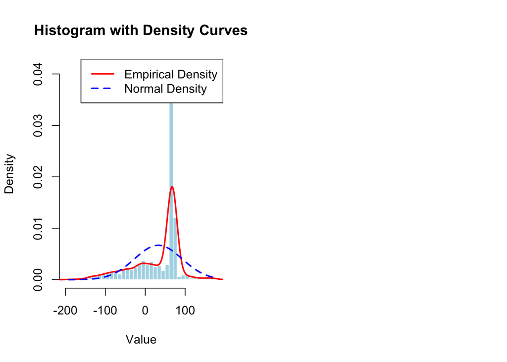

```r
# draw histogram
par(mfrow = c(1, 2))
hist(my.data, breaks = 30, probability = TRUE,
     main = "Histogram with Density Curves",
     xlab = "Value", col = "lightblue", border = "white")

# superimpose empirical density (using kernel density estimation)
lines(density(my.data), col = "red", lwd = 2)

# superimpose normal density (using sample’s mean and standard deviation)
x <- seq(min(my.data), max(my.data), length = 100)
lines(x, dnorm(x, mean = mean(my.data), sd = sd(my.data)),
      col = "blue", lwd = 2, lty = 2)

legend("topright", legend = c("Empirical Density", "Normal Density"),
       col = c("red", "blue"), lwd = 2, lty = c(1, 2))
```

Analysis: The red empirical curve is not symmetric — it shows two peaks (one around -2, another near 67.6)

The blue normal curve is smooth and bell-shaped but does not fit well — because the data is not normally distributed.

This occurs since the data comes from two distinct normal distributions, not a single one.

Normal density:

- assumes that data is normally distributed
- uses sample’s mean and standard deviation to fit the curve.

It shows what the data would look like if it followed a normal distribution.

### Plot ecdf

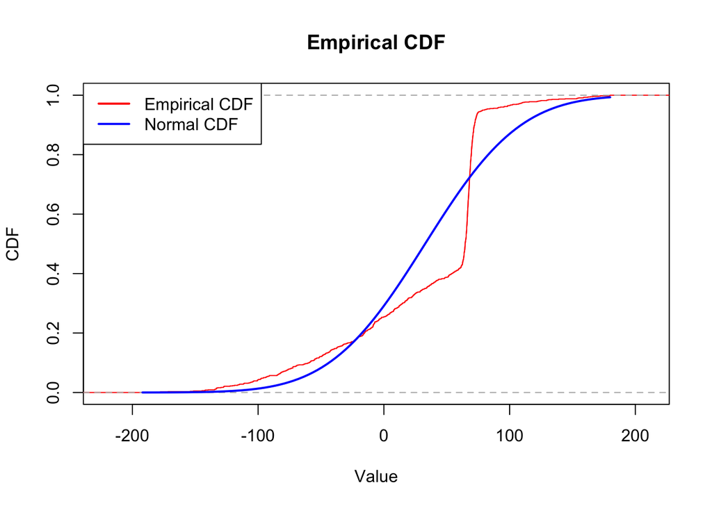

```r
# plot ecdf
plot(ecdf(my.data), main = "Empirical CDF",
     xlab = "Value", ylab = "CDF", col = "red")
# superimpose cdf for standard normal
lines(x, pnorm(x, mean = mean(my.data), sd = sd(my.data)),
      col = "blue", lwd = 2)

legend("topleft", legend = c("Empirical CDF", "Normal CDF"),
       col = c("red", "blue"), lwd = 2)
```

```r
# calculate maximal difference  (max vertical distance between the empirical CDF and the theoretical normal CDF)
ks_test <- ks.test(my.data, "pnorm", mean = mean(my.data), sd = sd(my.data))
cat("Maximal difference (KS statistic):", ks_test$statistic, "\n")
```

```
## Maximal difference (KS statistic): 0.2635929
```

Analysis: Empirical CDF climbs sharply around 60–80.

That steep jump means a lot of data is concentrated there, more than a normal curve would expect.

## 3. Skewness and kurtosis of the data

(skewness measures how symmetric the data is around the mean)

(kurtosis measures how “peaked” or “flat” a distribution is relative to the normal)

Positive skewness means the data have longer right tail and then the mean value $\mathsf{E}(X)$ is greater than the median

**Kurtosis** is defined as
$$\mathsf{E} \left[\left({\frac {X-\mu }{\sigma
}}\right)^{4}\right]={\frac {\mu _{4}}{\sigma ^{4}}}={\frac {\mathsf{E}
\left[(X-\mu )^{4}\right]}{\ \ \ (\mathsf{E} \left[(X-\mu
)^{2}\right])^{2}}}$$

For a standard normal distribution, the kurtosis is $3$. If we get a larger value, then more data are concentrated near the mean, and the empirical density is more steep

```r
# skewness
skewness <- function(x) {
  n <- length(x)
  mean_diff <- x - mean(x)
  skew <- (sum(mean_diff^3)/n) / (sum(mean_diff^2)/n)^(3/2)
  return(skew)
}

# kurtosis
kurtosis <- function(x) {
  n <- length(x)
  mean_diff <- x - mean(x)
  kurt <- (sum(mean_diff^4)/n) / (sum(mean_diff^2)/n)^2
  return(kurt)
}

cat("Skewness:", skewness(my.data), "\n")
```

```
## Skewness: -1.111987
```

```r
cat("Kurtosis:", kurtosis(my.data), "\n")
```

```
## Kurtosis: 3.866626
```

```r
cat("Excess Kurtosis (relative to normal):", kurtosis(my.data) - 3, "\n")
```

```
## Excess Kurtosis (relative to normal): 0.8666258
```

Analysis: Data is negatively skewed (-1.111987 ), the left tail is longer.

Kurtosis is 3.866626, which means that data is leptokurtic.

The distribution has: A sharper central peak, and heavier tails (more extreme values) than a normal curve.

## 4. Percentiles

### For q= 0.1,…,0.9 calculate sample q-percentiles manually (i.e. by sorting the data and picking the corresponding values) and by using percentile

(The q-th percentile is the value below which q × 100% of the data fall)

```r
sorted_data <- sort(my.data)
q_values <- seq(0.1, 0.9, by = 0.1)

# Manual percentiles
manual_percentiles <- sapply(q_values, function(q) {
  index <- q * length(sorted_data)
  if (index == floor(index)) {
    return(sorted_data[index])
  } else {
    return(sorted_data[ceiling(index)])
  }
})

# Using quantile function
r_percentiles <- quantile(my.data, probs = q_values)

# Compare results
percentile_comparison <- data.frame(
  Quantile = q_values,
  Manual = manual_percentiles,
  R_Function = r_percentiles,
  Difference = manual_percentiles - r_percentiles
)

print(percentile_comparison)
```

```
##     Quantile    Manual R_Function   Difference
## 10%      0.1 -59.70496  -59.42738 -0.277586254
## 20%      0.2 -15.61857  -15.39180 -0.226772469
## 30%      0.3  14.91675   14.90817  0.008580497
## 40%      0.4  53.83239   54.17628 -0.343894697
## 50%      0.5  64.65754   64.66775 -0.010217754
## 60%      0.6  66.48268   66.48482 -0.002134469
## 70%      0.7  67.89798   67.88802  0.009962538
## 80%      0.8  69.49888   69.50105 -0.002165377
## 90%      0.9  72.08818   72.09053 -0.002351982
```

Analysis: The differences between manual and R’s quantile() results are close to 0.

This is because R uses interpolation, while the manual version just rounds up. Still both are calculating correctly. (interpolation is a way to estimate values in between known data points)

Upper percentiles (50–90%) are around 65–70 - from the first distribution centered near 67.6.

## 5. Sample mean and sample standard error vs the theoretical ones

### What is the theoretical expected value of the random variable considered? What is the variance? Compare them to the sample values; explain the difference in the variance

```r
# theoretical expected value and variance

# sample mean and sample variance
theoretical_mean <- (mu1 + mu2) / 2
theoretical_var <- (sd1^2 + sd2^2 + (mu1 - theoretical_mean)^2 + (mu2 - theoretical_mean)^2) / 2

# Sample statistics
sample_mean <- mean(my.data)
sample_var <- var(my.data)
sample_sd <- sd(my.data)

cat("Theoretical mean:", theoretical_mean, "\n")
```

```
## Theoretical mean: 32.8
```

```r
cat("Sample mean:", sample_mean, "\n")
```

```
## Sample mean: 32.77297
```

```r
cat("Difference in means:", sample_mean - theoretical_mean, "\n\n")
```

```
## Difference in means: -0.02702772
```

```r
cat("Theoretical variance:", theoretical_var, "\n")
```

```
## Theoretical variance: 3500.42
```

```r
cat("Sample variance:", sample_var, "\n")
```

```
## Sample variance: 3558.276
```

```r
cat("Difference in variances:", sample_var - theoretical_var, "\n")
```

```
## Difference in variances: 57.85556
```

Analysis: The sample mean is almost identical to the theoretical one (difference = 0.03).

This is expected because we have a large sample (n = 1000), so the law of large numbers ensures that the sample mean converges to the true expected value

The sample variance (3558.3) is slightly higher than the theoretical (3500.4). Reason:

Sampling variability - random samples rarely match the exact population variance.

Mixture randomness - one of the groups (N(−2, (67.6)^2)) has a very wide spread, so a few extreme values can make the variance much larger in some samples.

## 6. k-sigma rule

### Calculate the fraction of the data that are within $k\sigma$ of the sample mean for $k=1,2,3$. Do we get the result expected? Why or why not?

```r
k_sigma_rule <- function(data, k_values = c(1, 2, 3)) {
  mean_val <- mean(data)
  sd_val <- sd(data)

  results <- sapply(k_values, function(k) {
    lower <- mean_val - k * sd_val
    upper <- mean_val + k * sd_val
    fraction <- mean(data >= lower & data <= upper)
    return(fraction)
  })

  return(data.frame(k = k_values, fraction_within = results))
}

# Apply k-sigma rule
k_results <- k_sigma_rule(my.data)
print(k_results)
```

```
##   k fraction_within
## 1 1           0.791
## 2 2           0.931
## 3 3           0.995
```

```r
# Expected values for normal distribution
expected_fractions <- c(0.6827, 0.9545, 0.9973)
k_results$expected <- expected_fractions
k_results$difference <- k_results$fraction_within - k_results$expected

print(k_results)
```

```
##   k fraction_within expected difference
## 1 1           0.791   0.6827     0.1083
## 2 2           0.931   0.9545    -0.0235
## 3 3           0.995   0.9973    -0.0023
```